# Proyecto #1

Daniel Segura Cruz

22/1/2025

# Práctica #1: Markdown

## Introducción a la Ciencia de Datos

La **ciencia de datos** es un campo que combina estadísticas, análisis de datos, aprendizaje automático y otras técnicas para extraer conocimiento útil de datos. Incluye conceptos importantes como análisis exploratorio de datos, **modelos predictivos** y sesgo de datos.

A continuación, exploraremos algunos aspectos clave de la ciencia de datos.

# Ciencia de Datos en química y matemática

En el análisis de datos en áreas como química, se utilizan expresiones como:  
* Dióxido de Carbono:CO<sub>2</sub>,Cloruro de Calcio:CaCl<sub>2</sub>,Ácido Sulfúrico:H<sub>2</sub>SO<sub>4</sub>,Amoníaco:NH<sub>3</sub>,Ácido Acético:CH<sub>3</sub>COOH.

- Y otras como Cloruro de Hidrógeno: HCl, Óxido de Magnesio: MgO, Cloruro de Sodio: Nacl.

En el análisis de datos en áreas como matemática, se utilizan expresiones como:

- e<sup>x</sup>,a<sup>x</sup>,f(x) y otras expresiones con superíndices.

# Procesos del análisis de datos

Para una visión general de la ciencia de datos, puedes visitar el articulo sobre

[Ciencia de Datos en Wikipedia](https://es.wikipedia.org/wiki/Ciencia_de_datos)  
Aquí tienes una imagen que ilustra el proceso de análisis de datos:

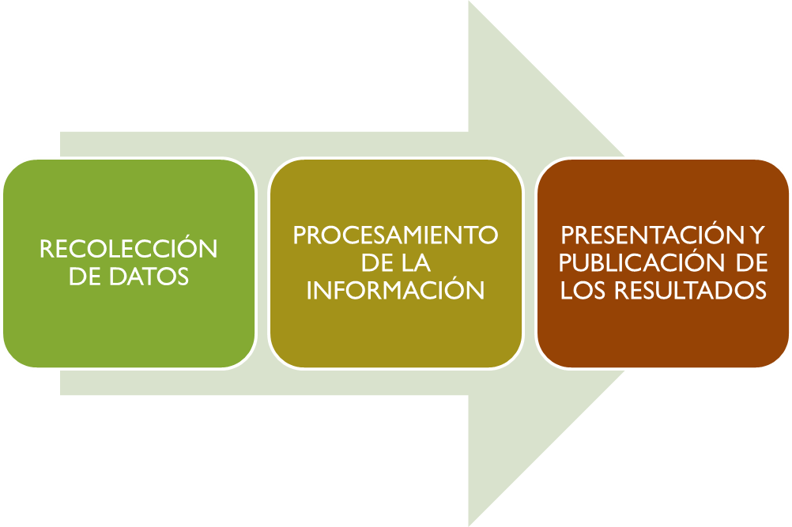

> “La ciencia de datos es el campo que proporciona las herramientas y los métodos para extraer conocimiento valioso a partir de grandes volúmenes de datos.”  
> **Dr.John Doe**

Pasos en un proyecto de ciencia de datos:

1. Recolección de datos
   1. Identificación de fuentes de datos
   2. Extracción de datos
   3. Almacenamiento de datos
2. Limpieza y preparación de datos
   1. Eliminación de duplicados
   2. Manejo de valores faltantes
   3. Transformación y normalización de datos
3. Análisis exploratorio de datos
   1. Análisis descriptivo
   2. Visualización de datos
   3. Identificación de patrones y tendencias
4. Construcción de modelos
   1. Selección de características
   2. Entrenamiento del modelo
   3. Ajuste de hiperparámetros
5. Evaluación de modelos
   1. Validación cruzada
   2. Evaluación de métricas (precisión, recall, F1-score, etc.)
   3. Comparación de modelos
6. Implementación y monitoreo
   1. Implementación en entorno de producción
   2. Monitoreo del rendimiento del modelo
   3. Actualización y mantenimiento del modelo

A continuación de muestra un ejemplo de una tabla con diferentes tipos de datos analizados:

| Tipo de Datos | Descripción | Ejemplo |
| --- | --- | --- |
| Datos Estructurados | Datos Organizados en tablas | Base de Datos SQL |
| Datos No Estructurados | Datos sin una estructura fija | Textos,imágenes |
| Datos SemiEstructurados | Datos con una estructura parcial | JSON,XML |

# Práctica #2: Código Matemático

1. $a^2+b^2=c^2$
2. $\displaystyle\int_{0}^{ \infty} e^{x-2}dx = \frac{\sqrt\pi}{2}$
3. $\lim_{x \to \infty} \frac{1}{x} = 0$
4. $\sum_{n=1}^\infty \frac{1}{n^2} = \frac{\pi^2}{6}$
5. $f(x)= \left\{\begin{matrix}x^2 & \text{si } x \geq 0\\-x & \text{si } x < 0\end{matrix}\right.$
6. $\sqrt[n]{x}=x^{1/n}$
7. $cos^{2}\theta +sin^{2}\theta =1$
8. $\binom{n}{k} = \frac{n!}{k!(n-k)!}$
9. $e^{i\pi}+1=0$
10. $\vec{v} =\begin{bmatrix}v_x \\v_y \\v_z\end{bmatrix}$
11. $\det(A) = \sum_{\sigma \in S_n} (\mathrm{sgn}\, \sigma) \prod_{i=1}^n a_{i, \sigma(i)}$
12. $\nabla \cdot \vec{F} = \frac{\partial F_x}{\partial x} + \frac{\partial F_y}{\partial y} + \frac{\partial F_z}{\partial z}$
13. $P(A \cap B) = P(A) \cdot P(B)$
14. $\begin{pmatrix}a + b & x - y & z^2 \\2i & n \cdot p & \sqrt{q} \\\sin\theta & e^\lambda & 3x +1 \end{pmatrix}$
15. $(\forall x \in \mathbb{R})(\exists y \in \mathbb{R})(x + y = 0)$
16. $\frac{d}{dx} \left( x^n \right) = n x^{n-1}$
17. $(A \neq \emptyset \land B \neq \emptyset) \implies A \cap B \neq \emptyset$
18. $|x|=\begin{cases} x & \text{si } x \geq 0, \\-x & \text{si } x < 0.\end{cases}$
19. $\log_a (xy) = \log_a x + \log_a y$
20. $lim_{h \to 0} \frac{f(x + h) - f(x)}{h}$
21. $a_n = a_{n-1} + a_{n-2}$
22. $\displaystyle\int_{0}^{1} x^n \, dx = \frac{1}{n+1}$
23. $\nabla f(x, y) =\begin{bmatrix}\frac{\partial f}{\partial x} \\\frac{\partial f}{\partial y}\end{bmatrix}$
24. $\int e^x \cos x \, dx = e^x \sin x + C$
25. $\text{Var}(X) = \mathbb{E}[X^2] - (\mathbb{E}[X])^2$
26. $y'' + 4y' - 5y = \sin(x)$
27. $x(t)= A\cos(\omega t+\phi)$
28. $\mathbb{P}(X \geq k) = \sum_{x=k}^\infty \mathbb{P}(X = x)$
29. $F(x) = \frac{1}{\sqrt{2\pi}} \int_{-\infty}^x e^{-t^2 / 2} \, dt$
30. $rank(A)=dim(Col(A))$

# Práctica #3: Código Programable

## Introducción

Este análisis utiliza la base de datos USArrests que contiene datos sobre arrestos por asalto, asesinato, violación y el porcentaje de población urbana en cada estado de Estados Unidos en 1973.

## Cargar Datos

Primero, cargamos la base de datos USArrests.

```r
#Cargar los datos
data("USArrests")
```

## Descripción de los Datos

Veamos los datos para entender su estructura

```r
#Mostrar la base de datos
USArrests
```

|  | Murder | Assault | UrbanPop | Rape |
| --- | --- | --- | --- | --- |
| Alabama | 13.2 | 236 | 58 | 21.2 |
| Alaska | 10.0 | 263 | 48 | 44.5 |
| Arizona | 8.1 | 294 | 80 | 31.0 |
| Arkansas | 8.8 | 190 | 50 | 19.5 |
| California | 9.0 | 276 | 91 | 40.6 |
| Colorado | 7.9 | 204 | 78 | 38.7 |
| Connecticut | 3.3 | 110 | 77 | 11.1 |
| Delaware | 5.9 | 238 | 72 | 15.8 |
| Florida | 15.4 | 335 | 80 | 31.9 |
| Georgia | 17.4 | 211 | 60 | 25.8 |

[output cut: 40 more lines]

El dataset contiene 50 filas (una por cada estado) y 4 columnas:

- Murder: tasa de asesinatos (por 100,000 habitantes).
- Assault: número de asaltos
- UrbanPop: porcentaje de población urbana.
- Rape: tasa de violaciones (por 100,000 habitantes).

## Resumen Estadístico

A continuación, un resumen estadístico de los datos.

```r
# Resumen estadístico
summary(USArrests)
```

```
##      Murder          Assault         UrbanPop          Rape
##  Min.   : 0.800   Min.   : 45.0   Min.   :32.00   Min.   : 7.30
##  1st Qu.: 4.075   1st Qu.:109.0   1st Qu.:54.50   1st Qu.:15.07
##  Median : 7.250   Median :159.0   Median :66.00   Median :20.10
##  Mean   : 7.788   Mean   :170.8   Mean   :65.54   Mean   :21.23
##  3rd Qu.:11.250   3rd Qu.:249.0   3rd Qu.:77.75   3rd Qu.:26.18
##  Max.   :17.400   Max.   :337.0   Max.   :91.00   Max.   :46.00
```

## Analisis de Correlación

Vea la correlación entre las variables.

```r
# Calcular la matriz de correlación
cor_matrix <- cor(USArrests)
cor_matrix
```

```
##              Murder   Assault   UrbanPop      Rape
## Murder   1.00000000 0.8018733 0.06957262 0.5635788
## Assault  0.80187331 1.0000000 0.25887170 0.6652412
## UrbanPop 0.06957262 0.2588717 1.00000000 0.4113412
## Rape     0.56357883 0.6652412 0.41134124 1.0000000
```

## Visualización de Datos

### Histogramas

Mostraremos histogramas para cada una de las variables.

[figure not shown]

```r
#Histogramas
par(mfrow= c(2,2))
hist(USArrests$Murder, main = "Histograma de Asesinatos", xlab = "Asesinatos")
hist(USArrests$Assault, main = "Histograma de Asaltos", xlab = "Asaltos")
hist(USArrests$Murder, main = "Histograma de Población Urbana", xlab = "Población Urbana (%)")
hist(USArrests$Rape, main = "Histograma de Violaciones", xlab = "Violaciones")
```

### Boxplots

Generemos boxplots para visualizar la dispersión y posibles outliners.

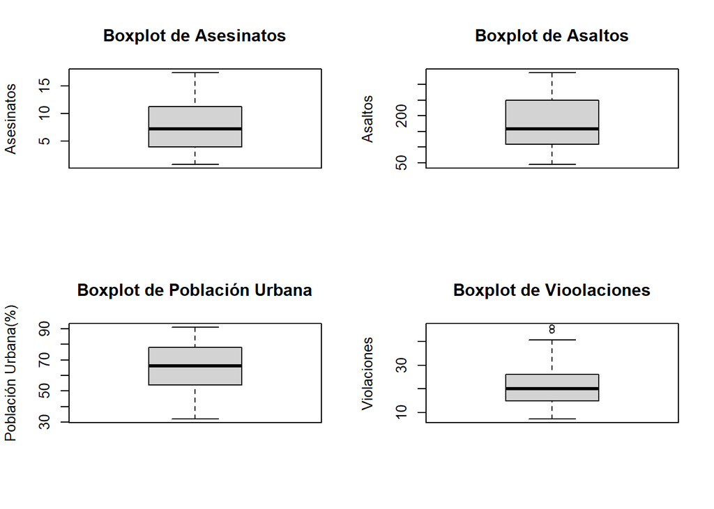

```r
par(mfrow = c(2,2))
boxplot(USArrests$Murder, main = "Boxplot de Asesinatos", ylab = "Asesinatos")
boxplot(USArrests$Assault, main = "Boxplot de Asaltos", ylab = "Asaltos")
boxplot(USArrests$UrbanPop, main = "Boxplot de Población Urbana", ylab = "Población Urbana(%)")
boxplot(USArrests$Rape, main = "Boxplot de Vioolaciones", ylab = "Violaciones")
```

### Pairs plot

Un pairs plot para ver las relaciones entre variables

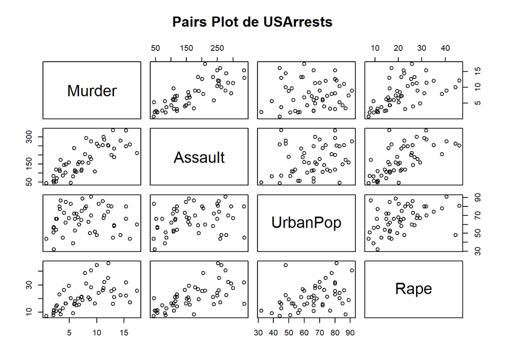

```r
pairs(USArrests, main = "Pairs Plot de USArrests")
```

### Mapa de Calor de Correlación

Visualicemos la matriz de correlación con un mapa de calor.

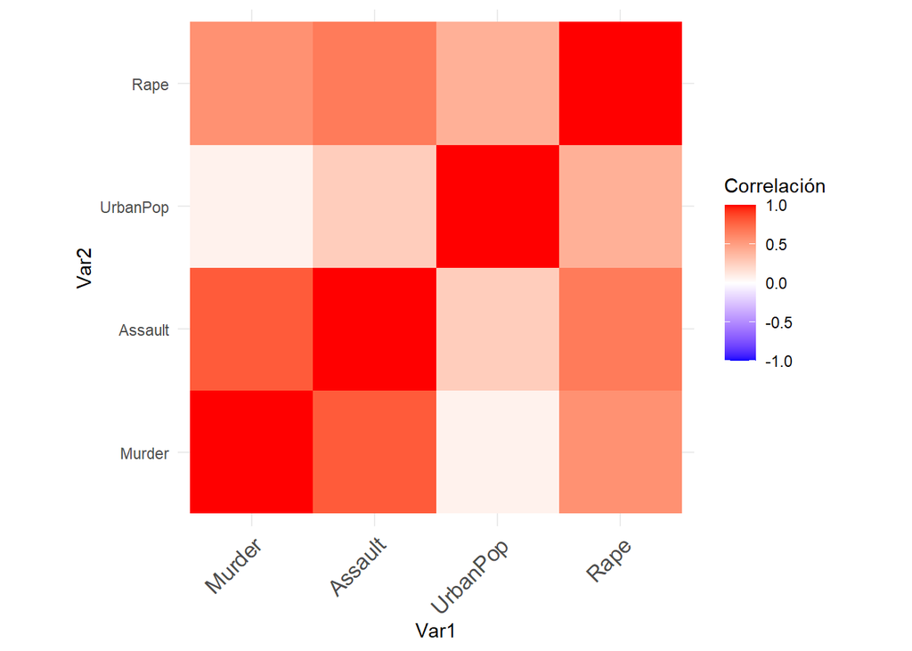

```r
# Cargar la librería ggplot2 y reshape2 para el mapa de calor
library(ggplot2)
library(reshape2)

# Transformar la matriz de correlación en formato largo
melted_cor_matrix <- melt(cor_matrix)

#Crear el mapa de calor
ggplot(data= melted_cor_matrix, aes(x = Var1, y = Var2, fill = value))+
  geom_tile()+
  scale_fill_gradient2(low="blue",high="red",mid="white",midpoint = 0, limit = c(-1,1), space ="Lab",name="Correlación")+
  theme_minimal()+
  theme(axis.text.x = element_text(angle= 45, vjust = 1,
                                   size = 12, hjust = 1)) +
  coord_fixed()
```

## Conclusiones

El análisis de los datos de `USArrests` revela varias obervaciones interesantes:

### Distribución de las Variables

- La tasa de asesinatos(`Murder`) varía significativamente entre los estados, con algunos estados con tasas mucho más altas que otros.
- El número de asaltos(`Assault`) muestra una mayor variabilidad comparada con otras variables.
- El porcentaje de población urbana (`UrbanPop`) está relativamente bien distribuido, con la mayoría de los estados teniendo entre 30% y 80% de población urbana.
- La tasa de violaciones (`Rape`) también muestra considerable variabilidad.

### Visualizaciones

Este análisis inicial proporciona una visión general de las tasas de crimen y la urbanización en los Estados Unidos en 1973. Para profundizar en el análisis, se podrían explorar más a fondo las relaciones causales y realizar un análisis espacial para ver como la geografía afecta las tasas de crimen.